# Basic Elements of Time Series

We can start the discussion on the basic elements of time series by using a practical example from real data made available through the R software. The data represent the global mean land–ocean temperature shifts from 1880 to 2015 (with base index being the average temperatures from 1951 to 1980) and this time series is represented in the plot below.

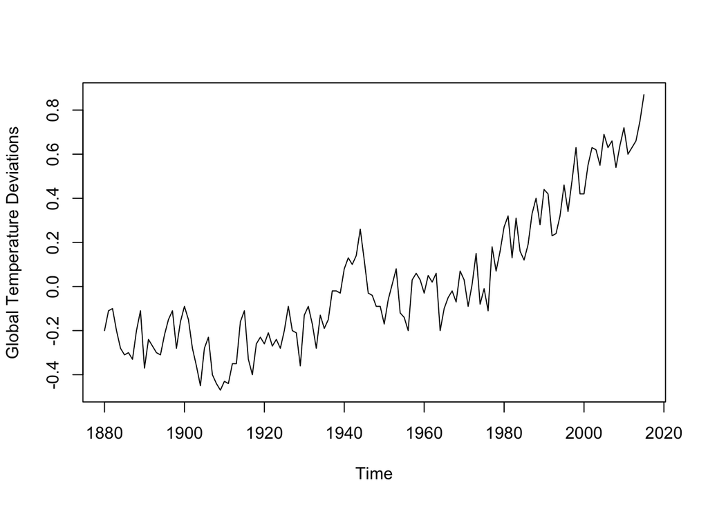

These data have been used as a support in favour of the argument that the global temperatures are increasing and that global warming has occured over the last half of the twentieth century. The first approach that one would take is to try and measure the average increase by fitting a (linear) model and testing if the (positive) slope is significant. In order to do so, we would require the residuals from the fitted model to independently and identically distributed (iid). Let us fit a model with the years (time) as explanatory variable and check the residuals from this fit.

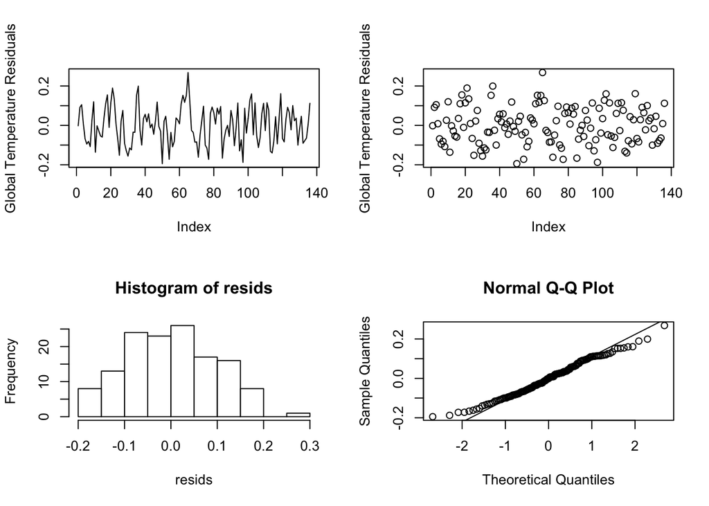

It can be seen from the upper left plot that the trend appears to be removed and, if looking at the residuals as one would usually do in a (linear) regression framework, the residual plots seem to suggest that the modelling has done a relatively good job since no particular pattern seems to emerge and their distribution is quite close to being Gaussian.

However, is it possible to conclude from the plots that the data are *iid*? More specifically, can we assume that the residuals are independent? This is a fundamental question in order for inference procedures to be carried out in an appropriate manner and to limit false conclusions. Let us provide an example through a simulated data set where we know that there is an upward trend through time (i.e. the slope $\beta = 0.01$) and our goal would be to show that this trend exists. Considering this, we simulate two cases where, in the first, the residuals are actually Gaussian iid while, in the second, the residuals are Gaussian but are dependent over time. The first case is shown below.

```r
set.seed(9)

# Simulate time series with iid residuals
y.ind <- cumsum(rep(0.01, 100)) + rnorm(100)

# Simulate time series with dependent residuals
y.dep <- cumsum(rep(0.01, 100)) + arima.sim(n = 100, list(ar = c(0.8897, -0.4858)))

# Define explanatory variable (time)
time <- 1:100

# Fit a linear model to estimate the slope (for the iid setting)
fit.ind <- lm(y.ind ~ time)
summary(fit.ind)
```

```
##
## Call:
## lm(formula = y.ind ~ time)
##
## Residuals:
##     Min      1Q  Median      3Q     Max
## -2.6000 -0.7028 -0.1409  0.4439  2.7085
##
## Coefficients:
##             Estimate Std. Error t value Pr(>|t|)
## (Intercept) 0.002092   0.194085   0.011  0.99142
## time        0.008899   0.003337   2.667  0.00895 **
## ---
## Signif. codes:  0 '***' 0.001 '**' 0.01 '*' 0.05 '.' 0.1 ' ' 1
##
## Residual standard error: 0.9632 on 98 degrees of freedom
## Multiple R-squared:  0.06767,    Adjusted R-squared:  0.05816
## F-statistic: 7.113 on 1 and 98 DF,  p-value: 0.008954
```

```r
# Fit a linear model to estimate the slope (for the dependent setting)
fit.dep <- lm(y.dep ~ time)
summary(fit.dep)
```

[output not shown]

As can be seen, the estimated slope ($\approx$ 0.009) is close to the true slope (0.01) and is significant (i.e. the p-value is smaller than the common rejection level 0.05). Hence, from this inference procedure we can conclude that the slope is significant and is roughly equal to 0.01 (which corresponds to the truth). However, let us explore the same analysis when the residuals are not independent.

```r
set.seed(9)

# Simulate time series with dependent residuals
y.dep <- cumsum(rep(0.01, 100)) + arima.sim(n = 100, list(ar = c(0.8897, -0.4858)))

# Define explanatory variable (time)
time <- 1:100

# Fit a linear model to estimate the slope (for the dependent setting)
fit.dep <- lm(y.dep ~ time)
summary(fit.dep)
```

```
##
## Call:
## lm(formula = y.dep ~ time)
##
## Residuals:
##     Min      1Q  Median      3Q     Max
## -3.2157 -0.9189 -0.1220  0.9663  3.6754
##
## Coefficients:
##             Estimate Std. Error t value Pr(>|t|)
## (Intercept) 0.276142   0.289520   0.954    0.343
## time        0.002288   0.004977   0.460    0.647
##
## Residual standard error: 1.437 on 98 degrees of freedom
## Multiple R-squared:  0.002152,   Adjusted R-squared:  -0.00803
## F-statistic: 0.2114 on 1 and 98 DF,  p-value: 0.6467
```

In this case we can observe that the p-value is greater than 0.05 and consequently the slope does not appear to be significant (although it is in reality). Therefore, the inference procedures can be misleading when not taking into account other possible significant variables or, in this case, forms of dependence that can hide true underlying effects.

The above examples therefore highlight how the approach to analysing time series does not only rely on finding an appropriate model that describes the evolution of a variable as a function of time (which is deterministic). Indeed, the main focus of time series analysis consists in modelling the dependence structure that describes how random variables impact each other as a function of time. In other words, a time series is a collection of random variables whose interaction and dependence structure is indexed by time.

## The Wold Decomposition

The previous discussion highlighted how a time series can be decomposed into a deterministic component and a random component. Leaving aside technical rigour, this characteristic of time series was put forward in Wold’s Decomposition Theorem who postulated that a time series $(Y_t)$ (where $t = 1,...,n$ represents the time index) can be very generically represented as follows:

$$Y_t = D_t + R_t,$$

where $D_t$ represents the deterministic part that can be modelled through the standard modelling techniques (e.g. linear regression) and $R_t$ that, restricting ourselves to a general class of processes, represents the random part that requires the analytical and modelling approaches that will be tackled in this book.

### The deterministic component

Before shifting our focus to the random component of time series, we will first just briefly underline the main features that should be taken into account for the deterministic component. The first feature that should be analysed is the *trend* that characterises the time series, more specifically the behaviour of the variable of interest as a specific function of time (as the global temperature time series seen earlier). Let us consider another example of time series based on real data, i.e. the quarterly earnings of Johnson & Johnson between 1960 and 1980 represented below.

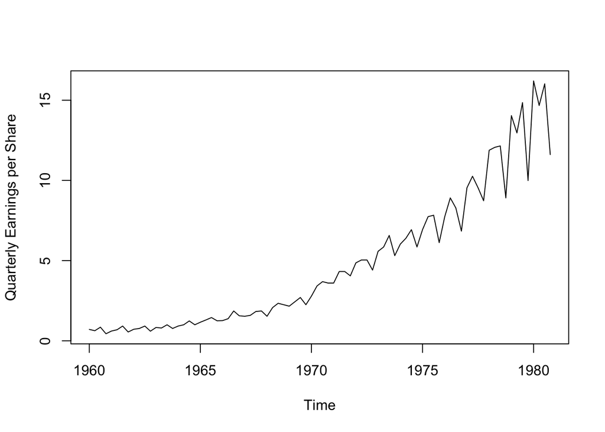

As can be seen from the plot, the earnings appear to grow over time, therefore we can imagine fitting a line to this data to describe its behaviour (see red line below).

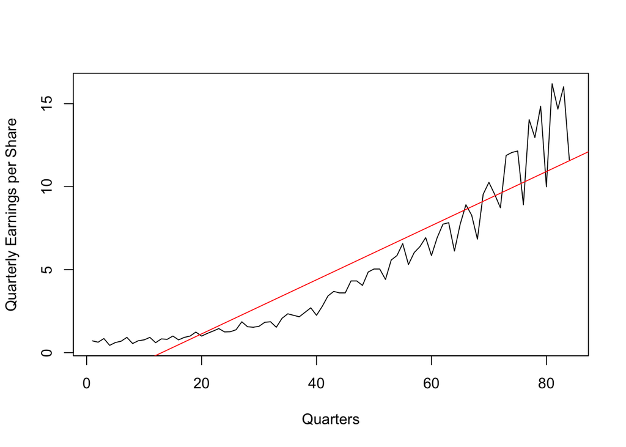

Although the line captures a part of the behaviour, it is quite clear that the trend of the time series is not linear. It could therefore be more appropriate to define another function of time to describe it and, consequently, we add a quadratic term of time to obtain the following fit.

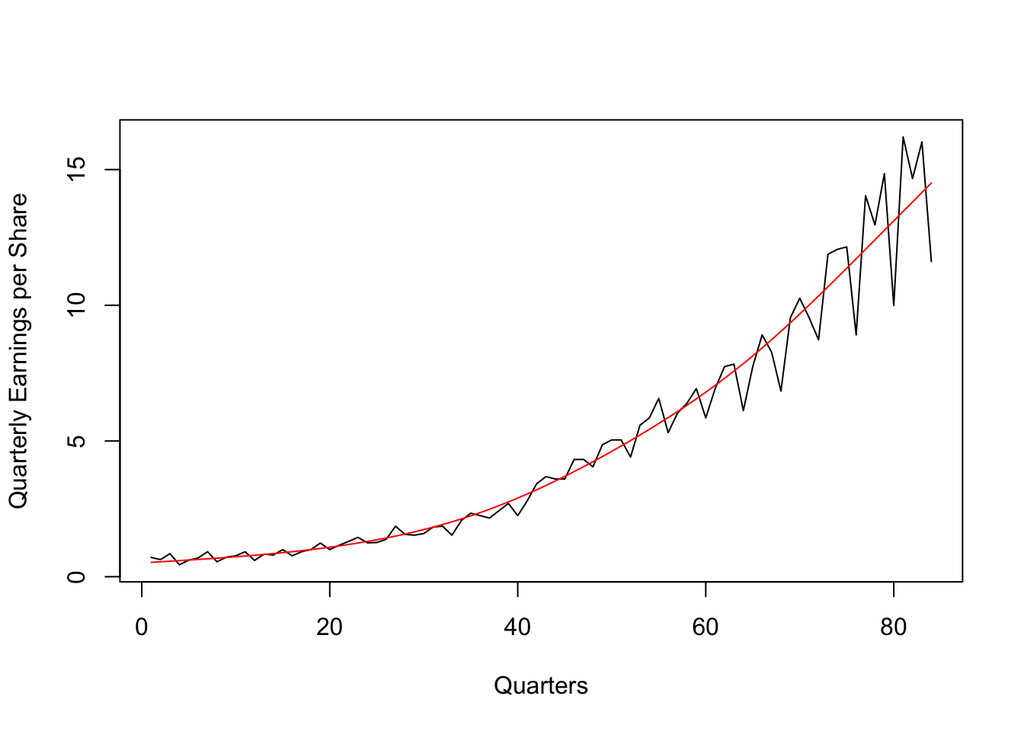

We can see now that the quadratic function of time allows to better fit the observed time series and closely follow the observations. However, there still appears to be a pattern in the data that isn’t captured by this quadratic model. This pattern appears to be repeated over time: peaks and valleys that seem to occur at regular intervals along the time series. This behaviour is known as *seasonality* which, in this case, can be explained by the effect of a specific quarter on the behaviour of the earnings. Indeed, it is reasonable to assume that the seasons have impacts on different variables measured over time (e.g. temperatures, earnings linked to sales that vary with seasons, etc.). Let us therefore take the quarters as an explanatory variable and add it to the previous quadratic model (see fit below).

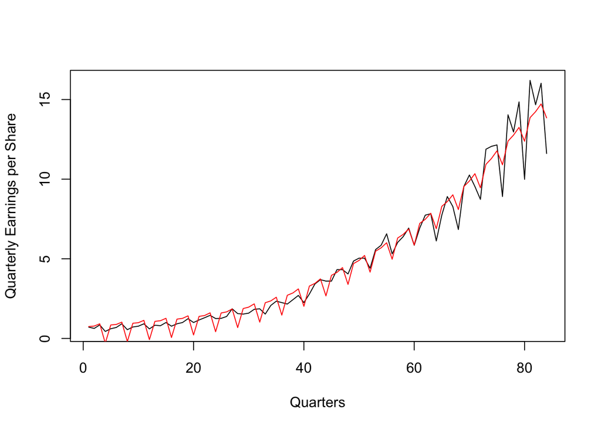

This final fit appears to well describe the behaviour of the earnings. Hence, *trend* and *seasonality* are the main features that characterize the deterministic component of a time series. However, as discussed earlier, these deterministic components often don’t explain all of the observed time series since there is often a random component characterizing data measured over time. Not considering the latter component can have considerable impacts on the inference procedures (as seen earlier) and it is therefore important to adequately analyse them (see next section).

### The random component

From this section onwards we will refer to *time series as being solely the random component* in the Wold Decomposition. Keeping this in mind, a *time series* is a particular kind of *stochastic process* which, generally speaking, is a collection of random variables indexed by a set of numbers. Not surprisingly, the index of reference for a time series is given by *time* and, consequently, a time series is a collection of random variables indexed (or “measured”) over time such as, for example, the daily price of a financial asset or the monthly average temperature in a given location. In terms of notation, a time series is often represented as

$$\left(X_1, X_2, ..., X_n \right) \;\;\; \text{ or } \;\;\; \left(X_t\right)_{t = 1,...,n}.$$

The time index $t$ is contained within either the set of reals, $\mathbb{R}$, or integers, $\mathbb{N}$. When $t \in \mathbb{R}$, the time series becomes a *continuous-time* stochastic process such a Brownian motion, a model used to represent the random movement of particles within a suspended liquid or gas. However, within this book, we will limit ourselves to the cases where $t \in \mathbb{N}$, better known as *discrete-time* processes. *Discrete-time* processes are where a variable is measured sequentially at fixed and equally spaced intervals in time.

This implies that we will have two assumptions:

1. $t$ is not random, e.g. the time at which each observation is measured is known, and
2. the time between two consecutive observations is constant.

Moreover, a time series can also be represented by a probability model for a set of observations. For example, one of the fundamental probability models used in time series analysis is called the *white noise* model and is defined as

$$X_t \mathop \sim \limits^{iid} N(0, \sigma^2).$$

Typically, we have $\mathbb{E}[Y_t] \neq 0$ while $\mathbb{E}[W_t] = 0$ (although we may have $\mathbb{E}[W_t | W_{t-1}, ..., W_1] \neq 0$). Such models impose some parametric structure which represents a convenient and flexible way of studying time series as well as a means to evaluate *future* values of the series through forecasting. As we will see, predicting future values is one of the main aspects of time series analysis. However, making predictions is often a daunting task or as famously stated by Nils Bohr:

> “*Prediction is very difficult, especially about the future.*”

There are plenty of examples of predictions that turned out to be completely erroneous. For example, three days before the 1929 crash, Irving Fisher, Professor of Economics at Yale University, famously predicted:

> “*Stock prices have reached what looks like a permanently high plateau*”.

Another example is given by Thomas Watson, president of IBM, who said in 1943:

> “*I think there is a world market for maybe five computers.*”